# Lab 1

Author

Ethan Schultz

Task 1

#1 It seems that we have a bubble plot here which maps out the income and life expectacy of different world regions. There is a fill attribute which allows up to see how the world regions differ in respect to their income and life expectancies. Also it seems there is a grouping aesthetics for the x variable of income which allows you to see it in four differernt levels. Along with the world regions there is another aesthetic which allows you to see the relative population size of each place within a world region based off the size of the bubble for it.

```python
#2
import pandas as pd
data1 = pd.read_csv("/Users/ethanschultz/Documents/GSB 544/Data Files/q1data.csv")
```

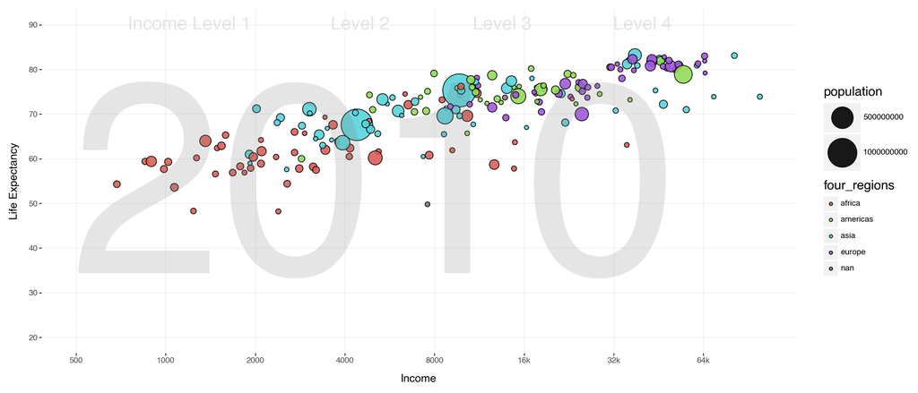

```python
#3
import plotnine as pl
(pl.ggplot(data1, pl.aes(x='income', y='life_exp', size='population', fill='four_regions'))
     + pl.geom_point(alpha=0.9)
     + pl.scale_size(range=(2, 20))
     + pl.annotate('text', x=5000, y=50, label=str('2010'), size=300, alpha =.2, color="gray")
     + pl.annotate('text', x=1200, y=90, label=str('Income Level 1'), size=20, alpha =.2, color="gray")
     + pl.annotate('text', x=4500, y=90, label=str('Level 2'), size=20, alpha =.2, color="gray")
     + pl.annotate('text', x=13500, y=90, label=str('Level 3'), size=20, alpha =.2, color="gray")
     + pl.annotate('text', x=40000, y=90, label=str('Level 4'), size=20, alpha =.2, color="gray")
     + pl.labs(x="Income", y="Life Expectancy")
     + pl.theme(axis_title=pl.element_text(size=12), title=pl.element_text(size=14), panel_background= pl.element_text(color="White"),
       panel_grid_major = pl.element_line(color="gray", alpha = 0.1), figure_size=(14,6))
     + pl.scale_x_log10(breaks = [500,1000,2000,4000,8000,16000,32000,64000],
     labels = ['500','1000','2000','4000','8000','16k','32k','64k'], limits = [500,100000])
     + pl.scale_y_continuous(limits =(20,90) , breaks = [20,30,40,50,60,70,80,90])
    )
```

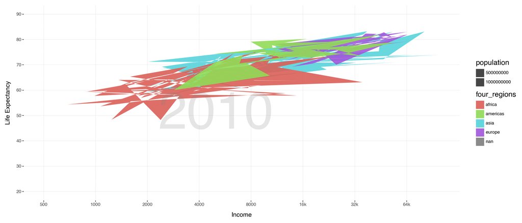

```python
#4
(pl.ggplot(data1, pl.aes(x='income', y='life_exp', size='population', fill='four_regions'))
     + pl.geom_polygon(alpha=0.9)
     + pl.scale_size(range=(2, 20))
     + pl.annotate('text', x=5000, y=50, label=str('2010'), size=100, alpha =.2, color="gray")
     + pl.labs(x="Income", y="Life Expectancy")
     + pl.theme(axis_title=pl.element_text(size=12), title=pl.element_text(size=14), panel_background= pl.element_text(color="White"),
       panel_grid_major = pl.element_line(color="gray", alpha = 0.1), figure_size=(14,6))
     + pl.scale_x_log10(breaks = [500,1000,2000,4000,8000,16000,32000,64000],
     labels = ['500','1000','2000','4000','8000','16k','32k','64k'], limits = [500,100000])
     + pl.scale_y_continuous(limits =(20,90) , breaks = [20,30,40,50,60,70,80,90])
    )
```

We see that instead of geom_point, geom_polygon is being used here. Clearly this visualization technique is not a good one for the data we have. It is very hard to differentiate the different values within each region and geom_polygon is probably a good geometry to use when there are not a lot of data point within each grouping region.

Task 2

#1 In this bubble plot we have Exports plotted against Imports for different countries. There is a fill asthetic here which groups the countires into their respective world regions which allows us to differentiate world regions by color on the plot. Then we have a size attribute for energy usage within each country which allows each bubble size to vary form country to country to differentiate energy usage.

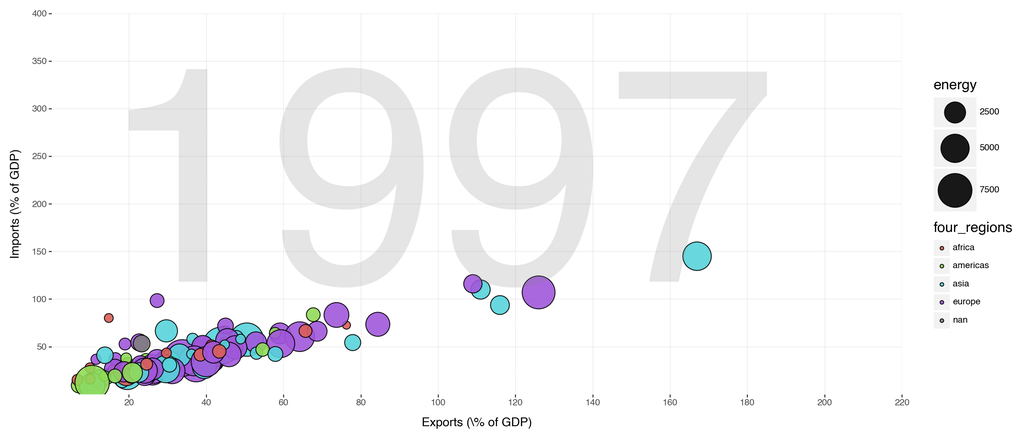

```python
#2
data2 = pd.read_csv("/Users/ethanschultz/Documents/GSB 544/Data Files/q2data.csv")
data2['four_regions'] = pd.Categorical(data2['four_regions'])
data2['exports'] = pd.to_numeric(data2['exports'], errors='coerce')
data2['imports'] = pd.to_numeric(data2['imports'], errors='coerce')
data2['energy'] = pd.to_numeric(data2['energy'], errors='coerce')

#3
(pl.ggplot(data2, pl.aes(x='exports', y='imports', size='energy', fill='four_regions'))
     + pl.geom_point(alpha=0.9)
     + pl.scale_size(range=(2, 20))
     + pl.annotate('text', x=100, y=200, label=str('1997'), size=300, alpha =.2, color="gray")
     + pl.labs(x="Exports (\% of GDP)", y="Imports (\% of GDP)")
     + pl.theme(axis_title=pl.element_text(size=12), title=pl.element_text(size=14), panel_background= pl.element_text(color="White"),
       panel_grid_major = pl.element_line(color="gray", alpha = 0.1), figure_size= (14,6))
     + pl.scale_x_continuous(limits=(0, 220), breaks=[20, 40, 60, 80, 100, 120, 140, 160, 180, 200, 220], expand=(0, 0))
     + pl.scale_y_continuous(limits=(0, 400), breaks=[50, 100, 150, 200, 250, 300, 350, 400], expand=(0, 0))
    )
```

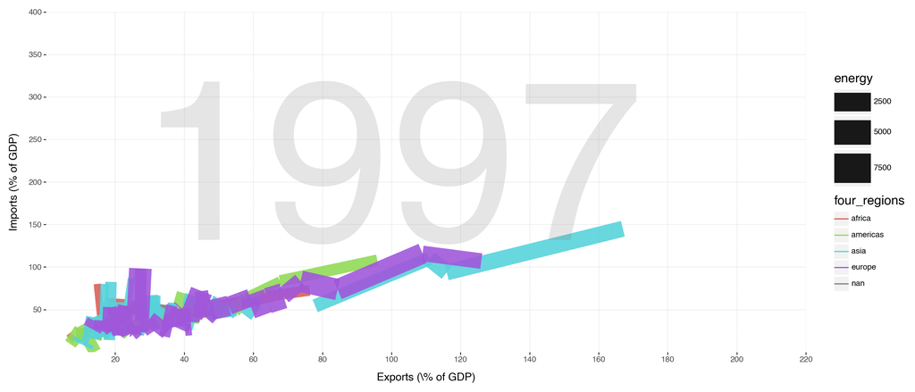

```python
#4
(pl.ggplot(data2, pl.aes(x='exports', y='imports', size='energy', color='four_regions'))
     + pl.geom_line(alpha=0.9)
     + pl.scale_size(range=(2, 20))
     + pl.annotate('text', x=100, y=200, label=str('1997'), size=250, alpha =.2, color="gray")
     + pl.labs(x="Exports (\% of GDP)", y="Imports (\% of GDP)")
     + pl.theme(axis_title=pl.element_text(size=12), title=pl.element_text(size=14), panel_background= pl.element_text(color="White"),
       panel_grid_major = pl.element_line(color="gray", alpha = 0.1), figure_size= (14,6))
     + pl.scale_x_continuous(limits=(0, 220), breaks=[20, 40, 60, 80, 100, 120, 140, 160, 180, 200, 220], expand=(0, 0))
     + pl.scale_y_continuous(limits=(0, 400), breaks=[50, 100, 150, 200, 250, 300, 350, 400], expand=(0, 0))
    )
```

The alternative geometry being used here is a geom_line which as we can see does not allow us to visualize the data better then when in points. This is probably because of the fact their are a lot of overlappping values especially in the lower left of the graph. This plot might be better used with data that has very different values for X and Y pairs. Also the size attribute is probably not the best options because as we can see just creates more overlap on the plotted lines.

Task 3

#1 In this bubble plot we have the number of individuals using the internet plotted against the GDP/capita of different countries. Their is another fill attribute which allows us to differentiate different world regions by color and the countries within those world regions. Another size attribute is used here but this time we have the income of those individuals using the interned as the size of the bubbles.

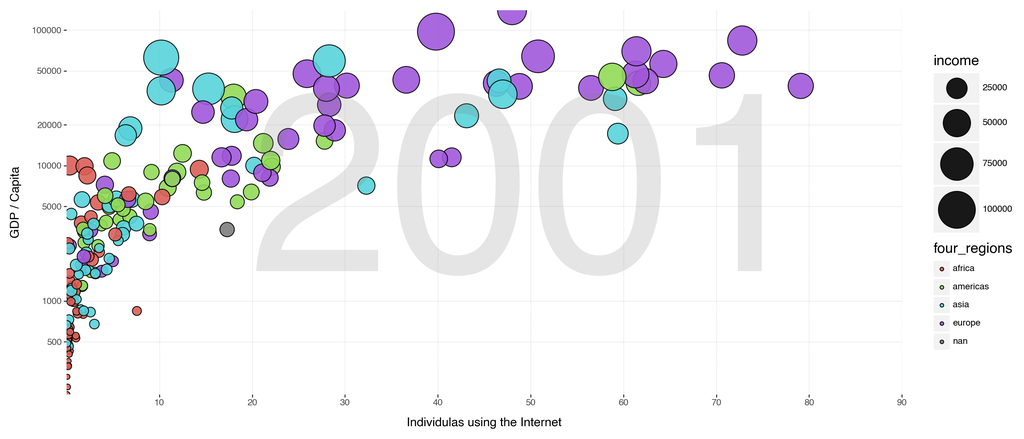

```python
#2
data3 = pd.read_csv("/Users/ethanschultz/Documents/GSB 544/Data Files/q3data.csv")

#3
(pl.ggplot(data3, pl.aes(x='internet_users', y='gdp', size='income', fill='four_regions'))
     + pl.geom_point(alpha=0.9)
     + pl.scale_size(range=(2, 20))
     + pl.annotate('text', x=50, y=5000, label=str('2001'), size=250, alpha =.2, color="gray")
     + pl.labs(x="Individulas using the Internet", y="GDP / Capita")
     + pl.theme(axis_title=pl.element_text(size=12), title=pl.element_text(size=14), panel_background= pl.element_text(color="White"),
       panel_grid_major = pl.element_line(color="gray", alpha = 0.1), figure_size=(14,6))
     + pl.scale_x_continuous(limits=(0, 90), breaks=[10, 20, 30, 40, 50, 60, 70, 80, 90], expand=(0, 0))
     + pl.scale_y_log10(breaks=[200, 500, 1000, 5000, 10000, 20000, 50000, 100000], expand=(0, 0))
    )
```

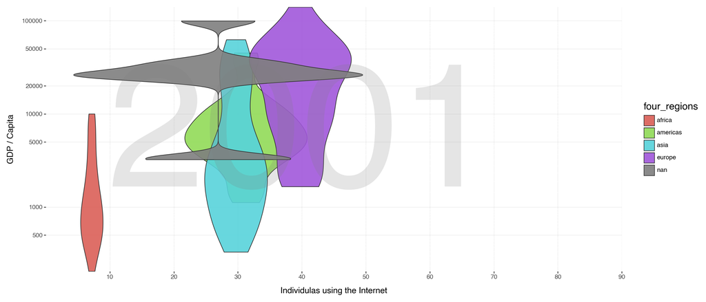

```python
#4
(pl.ggplot(data3, pl.aes(x='internet_users', y='gdp', size='income', fill='four_regions'))
     + pl.geom_violin(alpha=0.9)
     + pl.scale_size(range=(2, 20))
     + pl.annotate('text', x=40, y=5000, label=str('2001'), size=250, alpha =.2, color="gray")
     + pl.labs(x="Individulas using the Internet", y="GDP / Capita")
     + pl.theme(axis_title=pl.element_text(size=12), title=pl.element_text(size=14), panel_background= pl.element_text(color="White"),
       panel_grid_major = pl.element_line(color="gray", alpha = 0.1), figure_size=(14,6))
     + pl.scale_x_continuous(limits=(0, 90), breaks=[10, 20, 30, 40, 50, 60, 70, 80, 90], expand=(0, 0))
     + pl.scale_y_log10(breaks=[200, 500, 1000, 5000, 10000, 20000, 50000, 100000], expand=(0, 0))
    )
```

Here we have tried a geom_violin to plot this data and it does not do a better job than the geom_point. Again this plot might be useful for when we have data that each group, in this case world regions had more similar values plotted. We can see it doesnt really capture the differenation within each group as shown by all the values for Africa being at X values less than 10 but we can see from the geom_point plot this is not the case.